# Project 2 - Content-Based and Collaborative Filtering

Dhairav Chhatbar

6/11/2020

```r
library(dplyr)
library(tidyr)
library(kableExtra)
library(scales)
library(recommenderlab)
library(ggplot2)
```

The goal of this assignment is for you to try out different ways of implementing and configuring a recommender, and to evaluate your different approaches. Implement at least two of these recommendation algorithms:

- Content-Based Filtering
- User-User Collaborative Filtering
- Item-Item Collaborative Filtering

### Load Data

Load the the rating and movie title datasets and select a data set with the most relevant data, users that have rated atleaset 60 movies and movies that have been rated at least 150 times

```r
data("MovieLense")
movie_ratings <- MovieLense[rowCounts(MovieLense) > 60,  colCounts(MovieLense) > 150]
movie_ratings
```

```
## 492 x 200 rating matrix of class 'realRatingMatrix' with 38508 ratings.
```

### Exploratory

```r
all_ratings <- as.data.frame(as.vector(movie_ratings@data))
colnames(all_ratings) <- c("Rating")
```

The distribution of ratings show that most movies have not been rated and the matrix is sparse

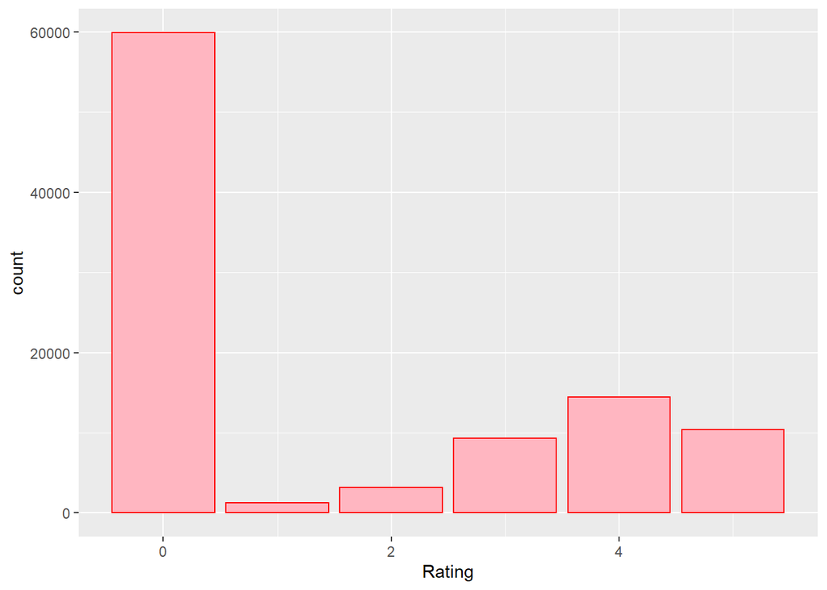

```r
ggplot(all_ratings, aes(Rating)) + geom_bar(color = "red", fill = "light pink")
```

When filtering out the 0 ratings, we see that most of the ratings are either 4 or 5 ratings, which indicates a level of bias. Normalization of the ratings will be needed. When looking at the average the distribution is not centered furthering the need for normalization

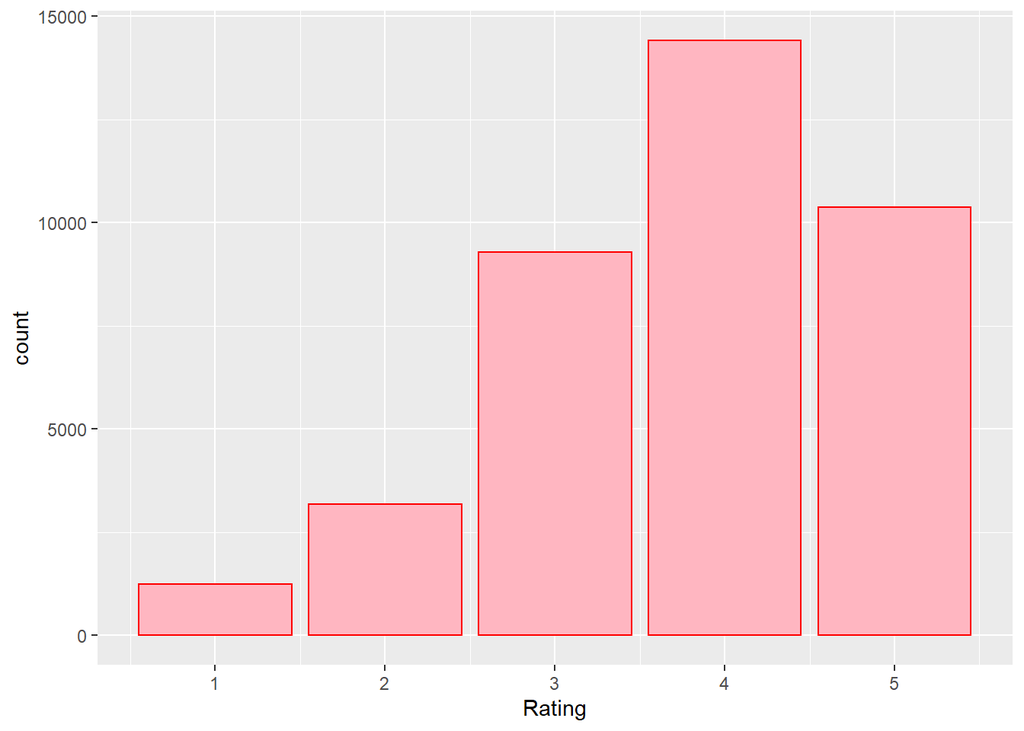

```r
ggplot(all_ratings %>% filter(Rating != 0), aes(Rating))+ geom_bar(color = "red", fill = "light pink")
```

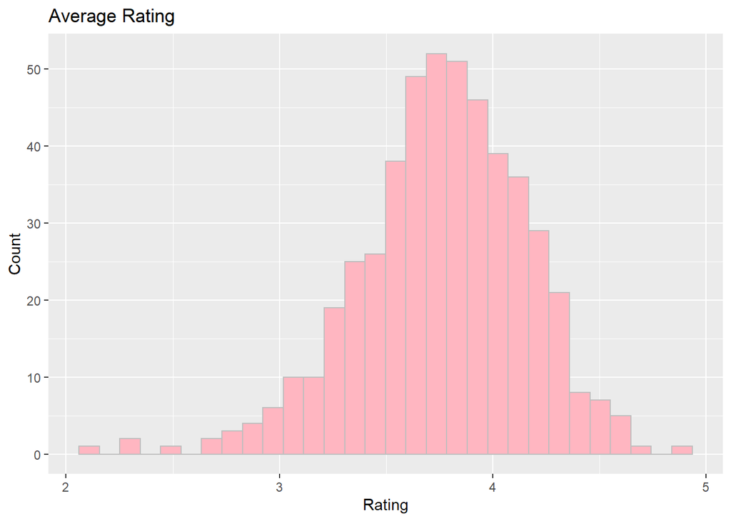

```r
avg_user_rating <- as.data.frame(rowMeans(movie_ratings))
ggplot(avg_user_rating, aes(x=avg_user_rating$`rowMeans(movie_ratings)`))+geom_histogram(fill="light pink", col="grey") + xlab("Rating") + labs(y="Count", title = "Average Rating")
```

List of 10 most rated movies by users and the least 10 rated movies. Notice that the top 10 rated movies are well known as “good” and popular movies

```r
all_movies <- as.data.frame(colCounts(movie_ratings))
colnames(all_movies) <- c("RatedCount")
head(all_movies %>% arrange(desc(RatedCount)), 10) %>% kable() %>% kable_styling(bootstrap_options = "striped", full_width = F)
```

|  | RatedCount |
| --- | --- |
| Star Wars (1977) | 409 |
| Return of the Jedi (1983) | 369 |
| Raiders of the Lost Ark (1981) | 359 |
| Fargo (1996) | 357 |
| Pulp Fiction (1994) | 334 |
| Toy Story (1995) | 333 |
| Independence Day (ID4) (1996) | 332 |
| Silence of the Lambs, The (1991) | 328 |
| Empire Strikes Back, The (1980) | 316 |
| Back to the Future (1985) | 313 |

```r
head(all_movies %>% arrange(RatedCount), 10) %>% kable() %>% kable_styling(bootstrap_options = "striped", full_width = F)
```

|  | RatedCount |
| --- | --- |
| Seven Years in Tibet (1997) | 73 |
| Everyone Says I Love You (1996) | 86 |
| Mother (1996) | 86 |
| Apt Pupil (1998) | 89 |
| G.I. Jane (1997) | 92 |
| Cop Land (1997) | 92 |
| George of the Jungle (1997) | 94 |
| Devil’s Advocate, The (1997) | 96 |
| Boogie Nights (1997) | 100 |
| Tomorrow Never Dies (1997) | 105 |

Looking at a heatmap of all the movies and ratings in scope we can see the sparsity in a row and column pattern where some users have rated more movies than others, and some movies are rated more than other movies

```r
movie_ratings_df <- getData.frame(movie_ratings)

ggplot(movie_ratings_df, aes(x=movie_ratings_df$item, y=movie_ratings_df$user, fill=movie_ratings_df$rating)) + geom_tile() +
  theme(axis.text.x = element_text(angle=90,hjust=0.95,vjust=0.2))
```

[figure not shown]

### Split Datasets

Split the data set into a training and test sets for both IBCF and UBCF sets with a 80% and 20% split respectively

```r
which_train <- sample(x = c(TRUE, FALSE), size = nrow(movie_ratings), replace = TRUE, prob = c(0.8, 0.2))
head(which_train)
```

```
## [1]  TRUE  TRUE  TRUE  TRUE FALSE FALSE
```

```r
train_ratings <- movie_ratings[which_train, ]
test_ratings <- movie_ratings[!which_train, ]

train_ratings_IBCF <- train_ratings
test_ratings_IBCF <- test_ratings

train_ratings_UBCF <- train_ratings
test_ratings_UBCF <- test_ratings

#Dimension of original data set
dim(movie_ratings)
```

```
## [1] 492 200
```

```r
#Dimension of training data set
dim(train_ratings)
```

```
## [1] 384 200
```

```r
#Dimension of test data set
dim(test_ratings)
```

```
## [1] 108 200
```

### Item Based Content Filtering

Given a user, the consider the user’s purchases and recommends similar items. Create a recommendation model on item similarity between users using a pearson difference method to find the 30 similar items for each user

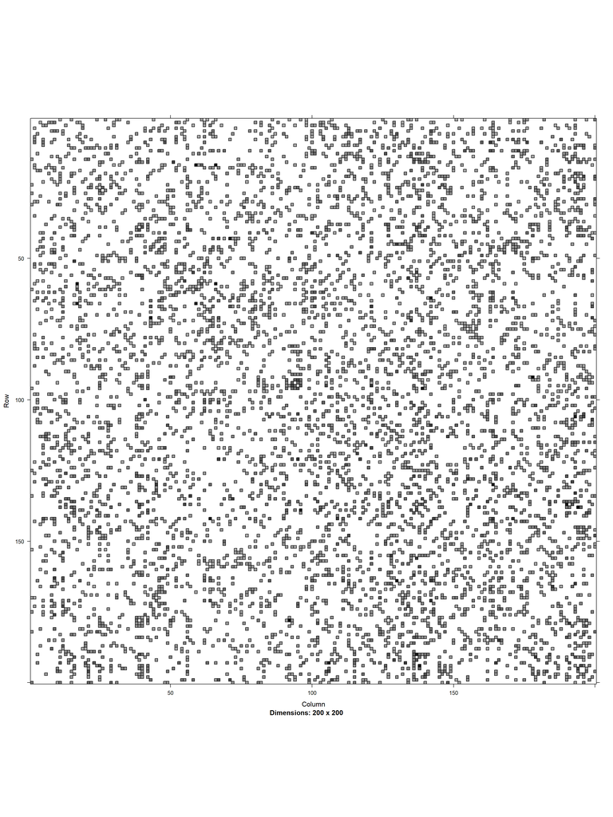

```r
model_IBCF <- Recommender(data = train_ratings_IBCF, method = "IBCF", parameter = list(k = 30, method = "pearson"))
IBCF <- getModel(model_IBCF)
image(IBCF$sim)
```

Most movie similarity were found to be amongst 10-20 users. Few common movies were found a small(<10) amount users or large(>20) around of users

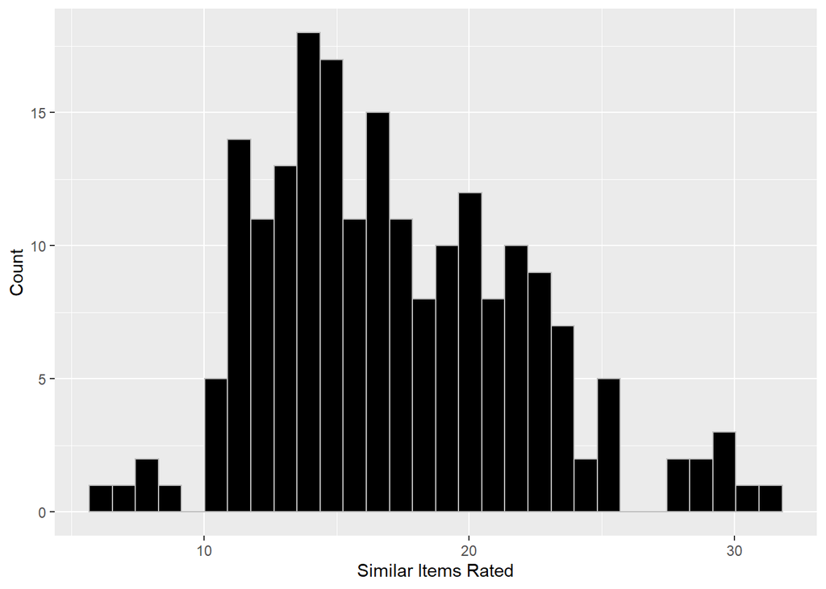

```r
t <- as.data.frame(colSums(IBCF$sim))
colnames(t) <- "Sim_Rated"

ggplot(t, aes(x=t$Sim_Rated))+geom_histogram(fill="black", col="grey")+xlab("Similar Items Rated")+ylab("Count")
```

After building the model and predicting movie recommendations (6 per user) for the test data set we see the movies recommended the most and the histogram shows a single movie was recommended to mostly 1-2 user, but very few movies were recommended across a large set of users

```r
to_recc <- 6
IBCF_pred <- predict(model_IBCF, test_ratings_IBCF, n=to_recc)
IBCF_pred
```

```
## Recommendations as 'topNList' with n = 6 for 108 users.
```

```r
recommended_IBCF <- sapply(IBCF_pred@items, function(x){colnames(movie_ratings)[x]})

recc_movie_sum_IBCF <- as.data.frame(table(as.factor(recommended_IBCF)))
colnames(recc_movie_sum_IBCF) <- c("Movie", "Frequency")

head(recc_movie_sum_IBCF %>% arrange(desc(Frequency)),10)
```

```
##                                     Movie Frequency
## 1  One Flew Over the Cuckoo's Nest (1975)        13
## 2                           Gandhi (1982)        12
## 3                        Big Night (1996)        11
## 4    Bridge on the River Kwai, The (1957)        11
## 5                 Dead Man Walking (1995)        11
## 6            2001: A Space Odyssey (1968)        10
## 7                   Apocalypse Now (1979)        10
## 8                       Casablanca (1942)        10
## 9                      Taxi Driver (1976)        10
## 10                  Godfather, The (1972)         9
```

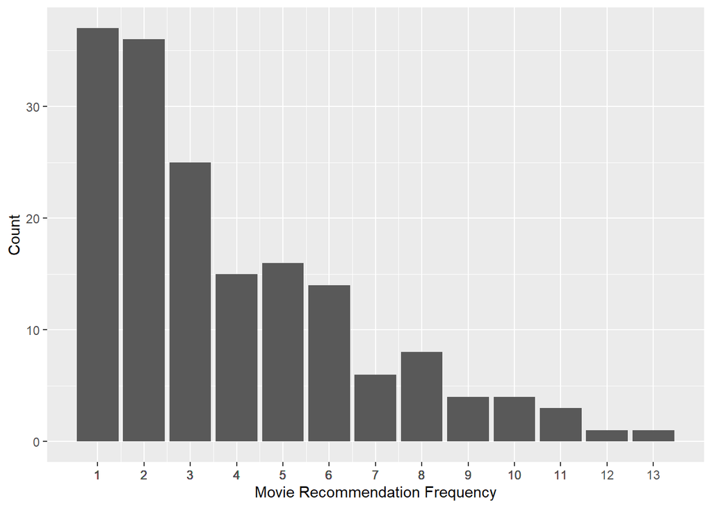

```r
ggplot(recc_movie_sum_IBCF, aes(x=Frequency)) + geom_bar() + scale_x_continuous("Movie Recommendation Frequency", labels = recc_movie_sum_IBCF$Frequency, breaks = recc_movie_sum_IBCF$Frequency) + ylab("Count")
```

We calculate the Root Square Mean Error for our predictions across various parameter changes:

- k: Number of similar items to find ranging from 1-200
- Similarity function: both Cosine and Pearson

Notice that using the pearson similarity function results in a smaller RMSE over the cosine similarity function

```r
eval <- evaluationScheme(movie_ratings, method = "cross-validation", k=3, goodRating=4, given=9)


calcPredictionAccuracy(predict(model_IBCF, getData(eval, "known"), type="ratings"), getData(eval, "unknown"))[1]
```

```
##     RMSE
## 1.102759
```

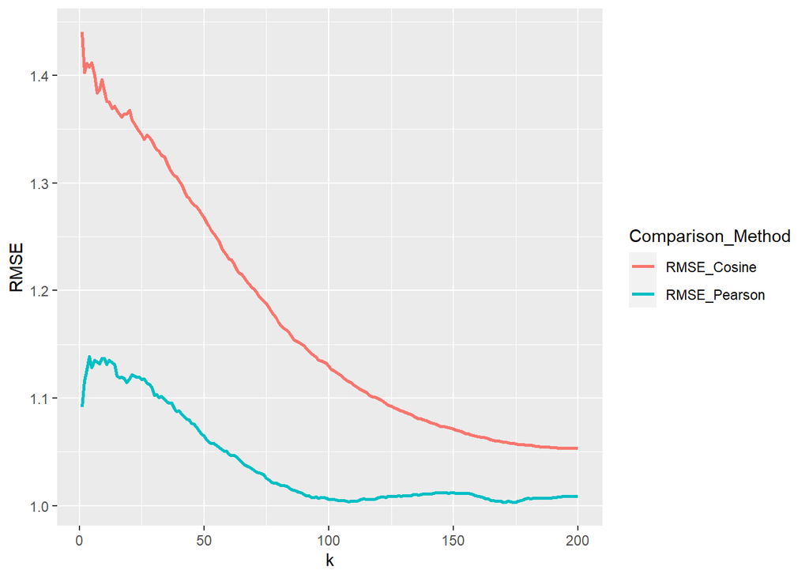

```r
k_val <- 1:ncol(movie_ratings)
RMSE_Pearson <- rep(0, ncol(movie_ratings))
RMSE_Cosine <- rep(0, ncol(movie_ratings))
algo_eval <- data.frame(k_val, RMSE_Pearson, RMSE_Cosine)

for(i in 1:ncol(movie_ratings))
{
  model_IBCF <- Recommender(data = train_ratings_IBCF, method = "IBCF", parameter = list(k = i, method = "pearson"))
  algo_eval$RMSE_Pearson[i] <- calcPredictionAccuracy(predict(model_IBCF, getData(eval, "known"), type="ratings"), getData(eval, "unknown"))[1]
  model_IBCF <- Recommender(data = train_ratings_IBCF, method = "IBCF", parameter = list(k = i, method = "cosine"))
   algo_eval$RMSE_Cosine[i] <- calcPredictionAccuracy(predict(model_IBCF, getData(eval, "known"), type="ratings"), getData(eval, "unknown"))[1]
}

algo_eval %>% gather(Comparison_Method,value, RMSE_Pearson, RMSE_Cosine) %>% ggplot(aes(x=`k_val`, y=value, colour=Comparison_Method)) + geom_line(size=1) + labs(x="k",y="RMSE")
```

### User Based Content Filtering

Another approach of recommendation is to take a given user and find similar users then, recommend the top-rated items purchased by similar users using the pearson similarity function

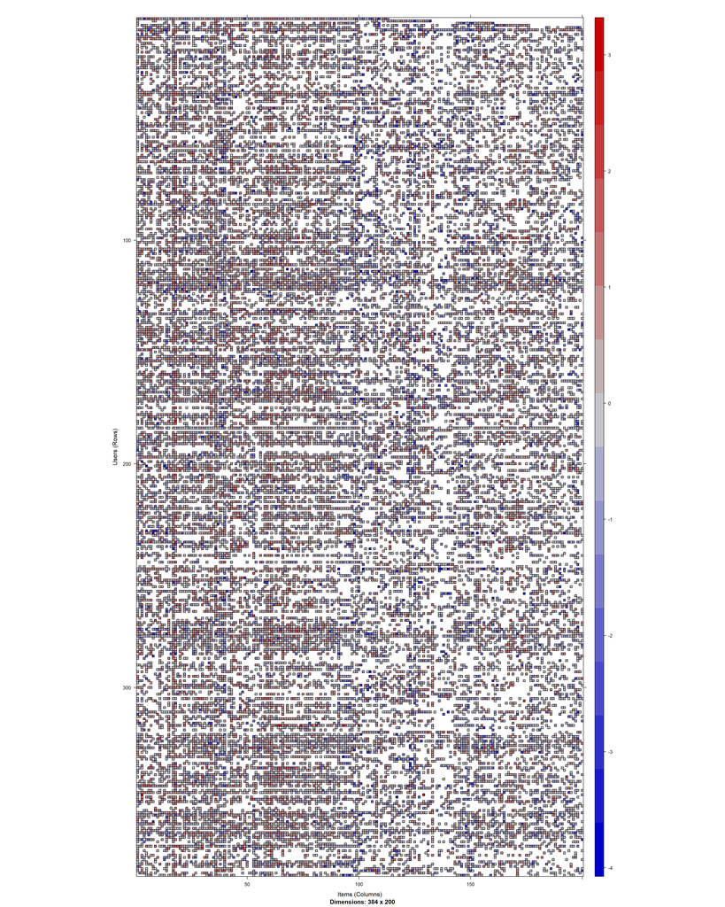

```r
model_UBCF <- Recommender(data = train_ratings_UBCF, method = "UBCF", parameter = list(method = "pearson"))
UBCF <- getModel(model_UBCF)
image(UBCF$data)
```

Using the UBCF recommendation model predict recommendations (6 per user) on the test data set. The most recommended movies are displayed as well as a histogram showing the distribution of movie recommendations. Note that as compared to IBCF, UBCF has movies that were recommended across a larger user base.

```r
to_recc <- 6
UBCF_pred <- predict(model_UBCF, test_ratings_UBCF, n=to_recc)
UBCF_pred
```

```
## Recommendations as 'topNList' with n = 6 for 108 users.
```

```r
recommended_UBCF <- sapply(UBCF_pred@items, function(x){colnames(movie_ratings)[x]})

recc_movie_sum_UBCF <- as.data.frame(table(as.factor(recommended_UBCF)))
colnames(recc_movie_sum_UBCF) <- c("Movie", "Frequency")

head(recc_movie_sum_UBCF %>% arrange(desc(Frequency)),10)
```

```
##                               Movie Frequency
## 1          Good Will Hunting (1997)        45
## 2          L.A. Confidential (1997)        45
## 3                    Titanic (1997)        42
## 4  Shawshank Redemption, The (1994)        28
## 5             Godfather, The (1972)        26
## 6                      Fargo (1996)        24
## 7           Schindler's List (1993)        24
## 8                 Casablanca (1942)        22
## 9             Secrets & Lies (1996)        17
## 10                 Star Wars (1977)        16
```

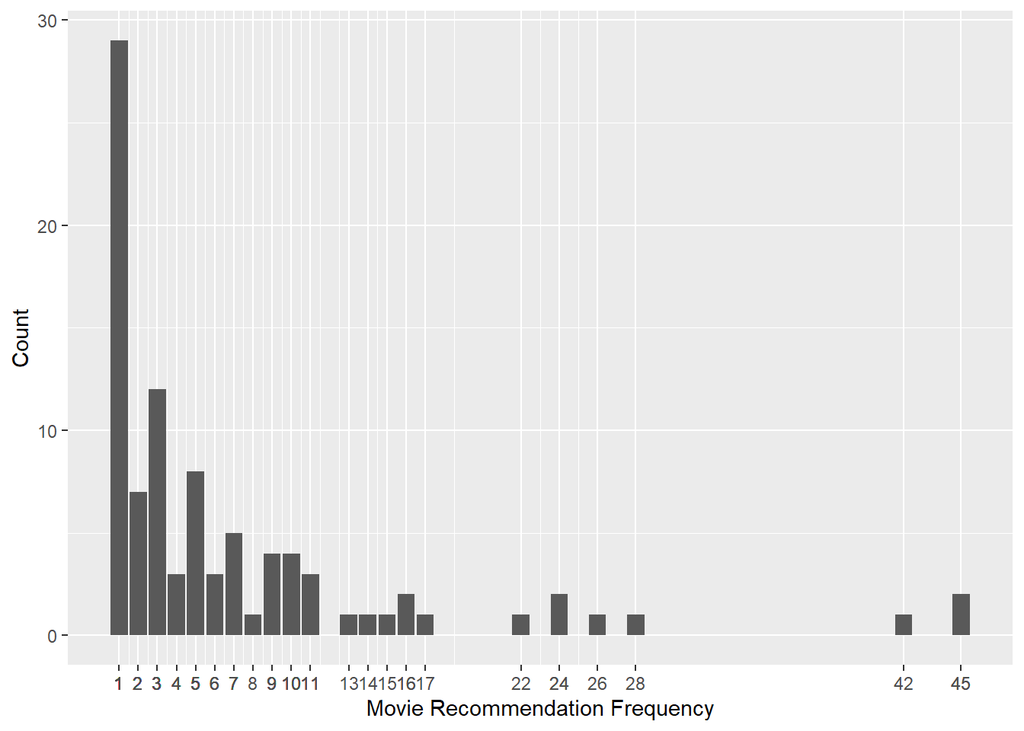

```r
ggplot(recc_movie_sum_UBCF, aes(x=Frequency)) + geom_bar() + scale_x_continuous("Movie Recommendation Frequency", labels = recc_movie_sum_UBCF$Frequency, breaks = recc_movie_sum_UBCF$Frequency) + ylab("Count")
```

We calculate the Root Square Mean Error for our predictions across various parameter changes:

- nn: the number of similar users ranging from 5-200
- Similarity function: both Cosine and Pearson

Notice that using the pearson similarity function results in a smaller RMSE over the cosine similarity function

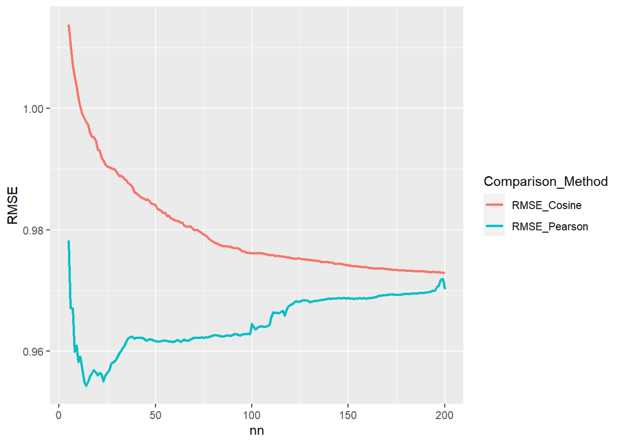

```r
eval2 <- evaluationScheme(movie_ratings, method = "split", train=.8, goodRating=4, given=9)

k_val <- 1:ncol(movie_ratings)
RMSE_Pearson <- rep(0, ncol(movie_ratings))
RMSE_Cosine <- rep(0, ncol(movie_ratings))
algo_eval2 <- data.frame(k_val, RMSE_Pearson, RMSE_Cosine)

for(i in 5:ncol(movie_ratings))
{
  model_UBCF <- Recommender(data = train_ratings_UBCF, method = "UBCF", parameter = list(nn=i, method = "pearson"))
  algo_eval2$RMSE_Pearson[i] <- calcPredictionAccuracy(predict(model_UBCF, getData(eval2, "known"), type="ratings"), getData(eval2, "unknown"))[1]
  model_UBCF <- Recommender(data = train_ratings_UBCF, method = "UBCF", parameter = list(nn=i, method = "cosine"))
   algo_eval2$RMSE_Cosine[i] <- calcPredictionAccuracy(predict(model_UBCF, getData(eval, "known"), type="ratings"), getData(eval, "unknown"))[1]
}

algo_eval2[5:nrow(algo_eval2),] %>% gather(Comparison_Method,value, RMSE_Pearson, RMSE_Cosine) %>% ggplot(aes(x=`k_val`, y=value, colour=Comparison_Method)) + geom_line(size=1) + labs(x="nn",y="RMSE")
```

### Summary

When recommending items to users using both an item based and user based content filtering approach we see that the UBCF with the pearson similarity function approach generates more recommendations at a lower RMSE